# import_template_automated

This is a template for importing eyetracking datasets to a peekbank schema compliant format with raw output files from automated eyetracking systems, such as SMI. In this template, we are using dataset *reflook_socword* as the example. This template relies on helper functions in the file import_helpers.R. Note that while we’ve tried to make these helper functions multipurpose, you’ll likely need to adapt them to your dataset as you go.

For automated coded eyetracking datasets, we will have nine processed tables at the end of this script: datasets, administrations, subjects, trial_types, trials, stimuli, xy_timepoints, aoi_region_sets, aoi_timepoints.

First, let’s load R packages and environment.

```r
library(here)
library(XML)
library(reader)
library(fs)
library(feather)
library(tidyverse)
library(peekds)
library(osfr)
library(kableExtra)
```

Then, set up general parameters and file paths. In this step, we will also download the raw files if they are not on our local machine.

```r
dataset_name <- "reflook_socword"
project_root <- here::here()
source(here("data/generic_import_template/smi/import_helpers.R"))
dataset_id <- 0
file_ext = '.txt'
OSF_ADDRESS <- "pr6wu"

# check raw data directory
raw_data_path <- fs::path(project_root, "data", dataset_name, "raw_data")
full_dataset_path <- fs::path(raw_data_path, "full_dataset")
exp_info_path <- fs::path(raw_data_path, "experiment_info")
aoi_path <- fs::path(raw_data_path, "test_aois")

# only download raw data if it's not on your local machine
if(length(list.files(full_dataset_path)) == 0 & length(list.files(exp_info_path)) == 0) {
  # check if raw_data_path exists to avoid generating an error in using get_raw_data
  if (!file.exists(raw_data_path)){
    dir.create(raw_data_path)
  }
  get_raw_data(lab_dataset_id = dataset_name, path = raw_data_path, osf_address = OSF_ADDRESS)
}

trial_file_name <- "reflook_v3_tests.csv"
participant_file_name <- "reflook_v3_demographics.csv"
# create participant file path
participant_file_path <- fs::path(exp_info_path, participant_file_name)
# create trial info file path
trial_file_path <- fs::path(exp_info_path, trial_file_name)
```

Let’s create the first `datasets` table. This table just has some information about the dataset, which we’ll just generate manually.

```r
df_dataset <- tibble(
  dataset_id = dataset_id,
  lab_dataset_id = dataset_name,
  dataset_name = dataset_name,
  cite = "Yurovsky, D., Wade, A., & Frank, M. (2013). Online processing of speech and social information in early word learning. In Proceedings of the annual meeting of the cognitive science society (Vol. 35, No. 35).",
  shortcite = "Yurovsky et al. (2013)"
)

df_dataset %>%
  kable() %>% kable_styling()
```

| dataset_id | lab_dataset_id | dataset_name | cite | shortcite |
| --- | --- | --- | --- | --- |
| 0 | reflook_socword | reflook_socword | Yurovsky, D., Wade, A., & Frank, M. (2013). Online processing of speech and social information in early word learning. In Proceedings of the annual meeting of the cognitive science society (Vol. 35, N… | Yurovsky et al. (2013) |

Next, let’s read in the area of interest (AOI) information. We’re using a custom helper function to do this, and you may need to write some custom code to load in your AOI information. If your AOI dimensions are in columns in your eyetracking data file rather than in a separate file, skip this step and get the AOI information after reading in the eyetracking data by grabbing distinct AOIs from that table.

We’ll create two tables: one that has the distinct sets of AOI regions and their dimensions, indexed with unique IDs, and one that connects trial types to these IDs. Only the `aoi_region_sets` will eventually be a table that is written and uploaded to peekbank; the correspondence between trial types and AOI IDs will later be used in the `trial_types` table. There’s only one set of AOI regions in this experiment, so all stimuli are linked to AOI region ID `0`.

```r
aoi_info_all <- process_smi_aoi(trial_file_name, exp_info_path)

# clean up aoi_region_sets
aoi_region_sets <- aoi_info_all %>%
  dplyr::select(-stimulus_name) %>%
  distinct() %>%
  mutate(aoi_region_set_id = seq(0,length(l_x_min)-1))

aoi_region_sets %>%
  kable() %>% kable_styling()
```

| l_x_min | l_x_max | l_y_min | l_y_max | r_x_min | r_x_max | r_y_min | r_y_max | aoi_region_set_id |
| --- | --- | --- | --- | --- | --- | --- | --- | --- |
| 0 | 555 | 262 | 788 | 1125 | 1680 | 262 | 788 | 0 |

```r
# create table of aoi region ids and trial types
# this information will later be added to the
aoi_ids <- aoi_info_all %>%
  left_join(aoi_region_sets, by = c("l_x_min", "l_x_max", "l_y_min", "l_y_max", "r_x_min", "r_x_max", "r_y_min", "r_y_max")) %>%
  distinct(stimulus_name, aoi_region_set_id)

aoi_ids %>%
  slice(1:5) %>%
  kable() %>% kable_styling()
```

| stimulus_name | aoi_region_set_id |
| --- | --- |
| manu1_manu2 | 0 |
| bosa2_bosa1 | 0 |
| book_dog | 0 |
| apple_frog | 0 |
| bosa1_bosa2 | 0 |

```r
##create stimuli data
stimuli_data <- process_smi_stimuli(trial_file_path) %>%
  mutate(stimulus_id = seq(0,length(stimulus_label)-1),
         original_stimulus_label = stimulus_label) %>%
  rename(english_stimulus_label = stimulus_label)

stimuli_data %>%
  slice(1:5) %>%
  kable() %>% kable_styling()
```

| stimulus_novelty | english_stimulus_label | dataset_id | stimulus_image_path | lab_stimulus_id | stimulus_id | original_stimulus_label |
| --- | --- | --- | --- | --- | --- | --- |
| novel | manu | 0 | NA | NA | 0 | manu |
| novel | manu_distractor | 0 | NA | NA | 1 | manu_distractor |
| novel | bosa_distractor | 0 | NA | NA | 2 | bosa_distractor |
| novel | bosa | 0 | NA | NA | 3 | bosa |
| familiar | book | 0 | NA | NA | 4 | book |

Now we’ll read in the actual eyetracking data. Again, we’re using a custom helper function here; you may need to write one as well. We want all the eyetracking data, with one row per time point, in a big table.

```r
# get all file paths in the directory with raw eyetracking data
all_files <- list.files(path = full_dataset_path,
                        pattern = paste0('*',file_ext),
                        all.files = FALSE)
# create file paths
all_file_paths <- fs::path(full_dataset_path, all_files)

# create eyetracking timepoint data
timepoint_data <- lapply(all_file_paths, process_smi_eyetracking_file)%>%
  bind_rows() %>%
  mutate(xy_timepoint_id = seq(0,length(lab_subject_id)-1)) %>%
  mutate(subject_id = as.numeric(factor(lab_subject_id, levels=unique(lab_subject_id)))-1) %>%
  mutate(trial_order = trial_type_id + 1,
         trial_id = trial_type_id)

timepoint_data %>%
  slice(1:5) %>%
  kable() %>% kable_styling()
```

| lab_subject_id | x | y | t | trial_type_id | xy_timepoint_id | subject_id | trial_order | trial_id |
| --- | --- | --- | --- | --- | --- | --- | --- | --- |
| 042412_01 | 364.08 | 602.16 | 0 | 0 | 0 | 0 | 1 | 0 |
| 042412_01 | 365.16 | 601.98 | 8 | 0 | 1 | 0 | 1 | 0 |
| 042412_01 | 378.41 | 596.88 | 17 | 0 | 2 | 0 | 1 | 0 |
| 042412_01 | 386.11 | 599.73 | 25 | 0 | 3 | 0 | 1 | 0 |
| 042412_01 | 390.49 | 596.70 | 33 | 0 | 4 | 0 | 1 | 0 |

Next, let’s make the `subjects` table. In this dataset, we have subject information in a separate file that’s linked to subject IDs in the timepoints table. We want to make sure to only include subjects we have data for in the `subjects` table, so we’ll get distinct subject IDs from the timepoints data and then join in other subject information from the separate subjects info file.

We’ll also create the `administrations` table. This is a table with information for each administration, or run of the experiment. It includes information about the eyetracker used and the size of the monitor. If your experiment is longitudinal, there may be multiple administrations per subject.

```r
## extract unique subjects ids from eyetracking data
participant_id_table <- timepoint_data %>%
  distinct(lab_subject_id, subject_id)

#create subject data
subjects_data <- process_subjects_info(participant_file_path) %>%
  left_join(participant_id_table, by="lab_subject_id") %>%
  filter(!is.na(subject_id)) %>%
  mutate(native_language = "eng") %>%
  dplyr::select(subject_id, sex, lab_subject_id, native_language)

subjects_data %>%
  slice(1:5) %>%
  kable() %>% kable_styling()
```

| subject_id | sex | lab_subject_id | native_language |
| --- | --- | --- | --- |
| 109 | male | _2012_1_17_78 | eng |
| 108 | male | _2012_1_21_77 | eng |
| 110 | male | _2012_1_21_79 | eng |
| 48 | female | _2012_11_12_8 | eng |
| 54 | female | _2012_11_15_18 | eng |

```r
# get monitor size and sample rate
monitor_xy <- extract_smi_info(all_file_paths[1], monitor_size)
sample_rate <- extract_smi_info(all_file_paths[1], sample_rate)

# get maximum x-y coordinates on screen
screen_xy <- str_split(monitor_xy, "x") %>%
  unlist()
x_max <- as.numeric(as.character(screen_xy[1]))
y_max <- as.numeric(as.character(screen_xy[2]))
```

```r
# create administration info
administration.data <- process_subjects_info(participant_file_path) %>%
    dplyr::select(lab_subject_id, age, lab_age, lab_age_units) %>%
    mutate(dataset_id = dataset_id,
           tracker = "SMI",
           monitor_size_x = x_max,
           monitor_size_y = y_max,
           sample_rate = sample_rate,
           coding_method = "eyetracking")

# use subjects table and join back in administration info to create final
# administration table
administration_data <- participant_id_table %>%
  left_join(administration.data, by = "lab_subject_id") %>%
  dplyr::select(dataset_id, subject_id, age, lab_age, lab_age_units,
                monitor_size_x, monitor_size_y, sample_rate, tracker, coding_method) %>%
  mutate(administration_id = seq(0,length(subject_id)-1))

administration_data %>%
  select(-lab_age) %>%
  slice(1:5) %>%
  kable() %>% kable_styling()
```

| dataset_id | subject_id | age | lab_age_units | monitor_size_x | monitor_size_y | sample_rate | tracker | coding_method | administration_id |
| --- | --- | --- | --- | --- | --- | --- | --- | --- | --- |
| 0 | 0 | 32 | years | 1680 | 1050 | 120 | SMI | eyetracking | 0 |
| 0 | 1 | 18 | years | 1680 | 1050 | 120 | SMI | eyetracking | 1 |
| 0 | 2 | 56 | years | 1680 | 1050 | 120 | SMI | eyetracking | 2 |
| 0 | 3 | 57 | years | 1680 | 1050 | 120 | SMI | eyetracking | 3 |
| 0 | 4 | 29 | years | 1680 | 1050 | 120 | SMI | eyetracking | 4 |

The `trial_types` table specifies different combinations of target items, distractor items, target sides (left or right), AOI region sets and so on–essentially, all the trial-level parameters.

```r
# create trials data
trials_data <- timepoint_data %>%
  distinct(trial_id, trial_order, trial_type_id)


trials_data %>%
  slice(1:5) %>%
  kable() %>% kable_styling()
```

| trial_type_id | trial_order | trial_id |
| --- | --- | --- |
| 0 | 1 | 0 |
| 1 | 2 | 1 |
| 2 | 3 | 2 |
| 3 | 4 | 3 |
| 4 | 5 | 4 |

```r
# create trials data and match with stimulus id and aoi_region_set_id
trial_types_data <- process_smi_trial_info(trial_file_path) %>%
  left_join(stimuli_data %>%
              select(stimulus_id, english_stimulus_label),
            by=c("distractor_label" = "english_stimulus_label")) %>%
  rename(distractor_id = stimulus_id) %>%
  left_join(stimuli_data %>% select(stimulus_id, english_stimulus_label),
            by=c("target_label" = "english_stimulus_label")) %>%
  rename(target_id = stimulus_id) %>%
  left_join(aoi_ids, by="stimulus_name") %>%
  mutate(condition = object_type) %>%
  mutate(full_phrase = paste0("Can you find the ", target_label, "?")) %>%
  dplyr::select(trial_type_id, full_phrase, full_phrase_language,
                point_of_disambiguation, target_side,
                lab_trial_id, aoi_region_set_id, dataset_id,
                distractor_id, target_id, condition)

trial_types_data %>%
  select(-lab_trial_id, -dataset_id) %>%
  slice(1:5) %>%
  kable() %>% kable_styling()
```

| trial_type_id | full_phrase | full_phrase_language | point_of_disambiguation | target_side | aoi_region_set_id | distractor_id | target_id | condition |
| --- | --- | --- | --- | --- | --- | --- | --- | --- |
| 0 | Can you find the manu? | eng | 2790 | left | 0 | 1 | 0 | extended |
| 1 | Can you find the bosa? | eng | 2860 | right | 0 | 2 | 3 | brief |
| 2 | Can you find the book? | eng | 2810 | left | 0 | 5 | 4 | familiar |
| 3 | Can you find the frog? | eng | 2720 | right | 0 | 6 | 7 | familiar |
| 4 | Can you find the bosa? | eng | 2860 | left | 0 | 2 | 3 | brief |

The timepoint eyetracking data needs to go through some processing to become two tables: `xy_timepoints`, which encodes the x and y coordinates of the subject’s eye movements at each time point, and `aoi_timepoints`, which encodes the AOI the subject is looking at (target, distractor, other, or missing) at each timepoint.

Right now, our data has time (in milliseconds) recorded starting at zero at the beginning of the experiment and counting upward for the entire length of the experiment. We’ll use some `peekds` functions to make this time consistent with the Peekbank schema. First, we’ll need to `rezero_times()`: make `t` restart at zero at the beginning of each trial. Next, we `normalize_times()`: within each trial, center time at the `point_of_disambiguation` (the onset of the target word). After this step, each trial will start at a negative timepoint and will iterate up to the `point_of_disambiguation`, which will be at `t` = 0; looking timepoints after the `point_of_disambiguation` will be positive. Finally, we will `resample_times()` so that the looking data are sampled at a consistent rate across all of Peekbank. If your data are already zeroed, you can skip that step; if they are already centered at the target onset, you only need to resample.

```r
# create xy data by merging in administration info and trial type info
xy_merged_data <- timepoint_data %>%
  mutate(dataset_id = dataset_id) %>%
  left_join(administration_data %>% select(subject_id, administration_id), by = "subject_id")%>%
  left_join(trial_types_data %>% select(trial_type_id,
                                        aoi_region_set_id,
                                        target_side,
                                        point_of_disambiguation), by = "trial_type_id") %>%
  left_join(aoi_region_sets, by = "aoi_region_set_id")

# select relevant columns for xy_timepoints
# rezero, normalize and resample times
xy_data <- xy_merged_data %>%
  dplyr::select(xy_timepoint_id,x,y,t, administration_id, trial_id, point_of_disambiguation) %>%
  peekds::rezero_times(.) %>%
  peekds::normalize_times(.) %>%
  peekds::resample_times(., table_type = "xy_timepoints") %>%
  select(xy_timepoint_id, x, y, t_norm, administration_id, trial_id)

xy_data %>%
  slice(1:5) %>%
  kable() %>% kable_styling()
```

| xy_timepoint_id | x | y | t_norm | administration_id | trial_id |
| --- | --- | --- | --- | --- | --- |
| 0 | 364.08 | 602.16 | -2800 | 0 | 0 |
| 1 | 365.16 | 601.98 | -2775 | 0 | 0 |
| 2 | 390.49 | 596.70 | -2750 | 0 | 0 |
| 3 | 387.52 | 600.38 | -2725 | 0 | 0 |
| 4 | 392.22 | 603.29 | -2700 | 0 | 0 |

```r
# create aoi data using peekds function add_aois()
# rezero, normalize and resample times
aoi_timepoints_data <- xy_merged_data %>%
  peekds::add_aois(.) %>%
  select(trial_id, administration_id, aoi, t, point_of_disambiguation) %>%
  peekds::rezero_times(.) %>%
  peekds::normalize_times(.) %>%
  peekds::resample_times(., table_type = "aoi_timepoints") %>%
  select(aoi_timepoint_id, trial_id, aoi, t_norm, administration_id)

aoi_timepoints_data %>%
  slice(1:5) %>%
  kable() %>% kable_styling()
```

| aoi_timepoint_id | trial_id | aoi | t_norm | administration_id |
| --- | --- | --- | --- | --- |
| 0 | 0 | target | -2800 | 0 |
| 1 | 0 | target | -2775 | 0 |
| 2 | 0 | target | -2750 | 0 |
| 3 | 0 | target | -2725 | 0 |
| 4 | 0 | target | -2700 | 0 |

That’s it! Now, we’ll write all the tables to `.csv` files and validate them to make sure they adhere to the schema. The osf write are commented out so you don’t accidentally write a bunch of stuff when running this script. There you have it–that’s how to import a Peekbank eyetracker dataset.

```r
output_path <- fs::path(project_root, "data", dataset_name, "processed_data")

# write_csv(df_dataset, file = here(output_path, "datasets.csv"))
# write_csv(subjects_data, file = here(output_path, "subjects.csv"))
# write_csv(stimuli_data, file = here(output_path,  "stimuli.csv"))
# write_csv(administration_data, file = here(output_path, "administrations.csv"))
# write_csv(trial_types_data, file = here(output_path, "trial_types.csv"))
# write_csv(trials_data, file = here(output_path, "trials.csv"))
# write_csv(aoi_region_sets, file = here(output_path, "aoi_region_sets.csv"))
# write_csv(xy_data, file = here(output_path, "xy_timepoints.csv"))
# write_csv(aoi_timepoints_data, file = here(output_path, "aoi_timepoints.csv"))

# run validation
# peekds::validate_for_db_import(dir_csv = output_path)

# OSF integration
# token <- read_lines(here("../token.txt"))[1] # please specific your own personal access token
# osf_token <- osf_auth(token = token)
# put_processed_data(osf_token, dataset_name, paste0(output_path,"/"), osf_address = OSF_ADDRESS)
```

Finally, we’ll create a simple visualization plot for this dataset.

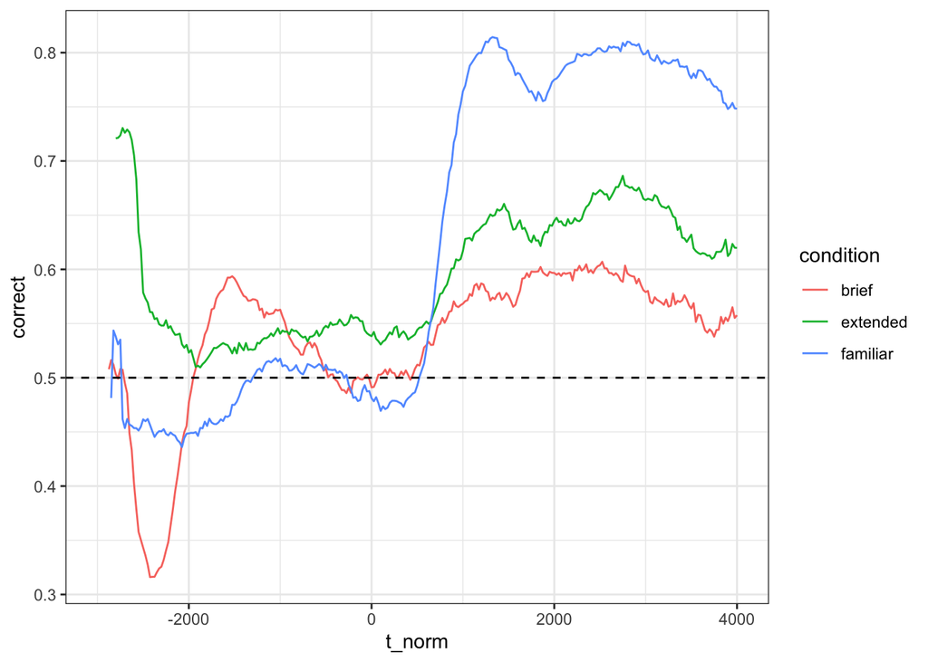

```r
aoi_timepoints_data %>%
  left_join(trials_data) %>%
  left_join(trial_types_data) %>%
  group_by(t_norm, condition) %>%
  filter(aoi %in% c("target", "distractor")) %>%
  summarise(correct = mean(aoi == "target")) %>%
  ggplot(aes(x = t_norm, y = correct, col = condition)) +
  geom_line() +
  xlim(-3000, 4000) +
  geom_hline(aes(yintercept = .5), lty = 2) +
  theme_bw()
```